# STAT-S632

Random Effects

**def** *fixed effect* - unknown constant that we try to estimate from the data

**def** *random effect* - random variable, we try to estimate its parameters; blocking factors can be viewed as random effects

When we say there are random effects, we are making some sort of assumption

**e.g.** Experiment to investigate the effect of several drug treatments

- Patient effects are treated as random
- Interested in the population, not individual patients

**def** *mixed effects* model has both fixed and random effects

**e.g.** ANOVA $y_{ijk} = \mu + \tau_i + \nu_j + \epsilon_{ijk}$,  
where $\mu$ and $\tau_i$ are fixed effects, $\epsilon_{ijk}$ is the error, and $\nu_j$ are the random effects, and $\epsilon_{ijk} \stackrel{iid}{\sim} \mathcal{N}(0, \sigma^2)$, $\nu_j \stackrel{iid}{\sim} \mathcal{N}(0, \sigma_\nu^2)$. One possible approach might be to estimate $\tau_i$ and test $H_1$ : $\tau_i \neq 0$ $\forall i$. We can also estimate $\sigma_\nu^2$ and test $H_1$ : $\sigma_\nu^2 \neq 0$. We need to estimate and test several fixed effects while we only estimate and test a single random effect parameter.

# Estimation

**e.g.** One-way ANOVA with a factor at $a$ levels

$$y_{ij} = \mu + \alpha_i + \epsilon_{ij}$$

for $i = 1, ..., a$ and $j = 1, ..., n$, $E[\alpha] = E[\epsilon] = 0$, $var(\alpha) = \sigma_\alpha^2$, $var(\epsilon) = \sigma_\epsilon^2$. Then we can define a correlation coefficient:

$$\rho = \frac{\sigma_\alpha^2}{\sigma_\alpha^2 + \sigma_\epsilon^2}$$

$\rho$ is the *intraclass correlation coefficient (ICC). When there is no variation between the levels of $\alpha$, $\sigma_\alpha^2 = 0$, so $\rho = 0$. When the variation between levels is much larger than the variation within levels, $\rho \rightarrow 1$.

Assume $n$ observations per level (equally distributed). Then

$$\sum_i^a \sum_j^n (y_{ij} - \bar{y}_{\cdot \cdot})^2 =
\sum_i^a \sum_j^n (y_{ij} - \bar{y}_{i \cdot})^2 +
\sum_i^a \sum_j^n (\bar{y}_{i \cdot} - \bar{y}_{\cdot \cdot})^2$$

… or SST (sum of squares total) = SSE (sum of squared errors) + SSA (sum of squares due to $\alpha$). If we divide SSE by its degrees of freedom, we obtain the MSE, and if we divide SSA by its degrees of freedom, we obtain the MSA. It can be shown that $E[SSE] = a (n-1) \sigma_\epsilon^2$ and $E[SSA] = (a-1) (n \sigma_\alpha^2 + \sigma_\epsilon^2)$. This suggests that we use the estimators $\hat{\sigma}_\epsilon^2 = \frac{SSE}{a (n-1)} = MSE$ and $\hat{\sigma}_\alpha^2 \frac{SSA / (a-1) - \hat{\sigma}_\epsilon^2}{n}$ $= \frac{MSA - MSE}{n}$. This has a few disadvantages:

- The estimates can be negative
- While the estimates are unique when the data are balanced across the levels, this is not necessarily the case for uneven data
- Can result in complicated algebraic calculations

Instead, perhaps a maximum likelihood estimation method would be better. For this, we need to assume some distribution for the errors and random effects (e.g., normal).

For a fixed effect model with normal errors, $y \sim \mathcal{N}(X \beta, \sigma^2 I)$. So for a random effects model, we can use:

$$y = X \beta + Z \gamma + \epsilon$$

$$y | \gamma \sim \mathcal{N}(X \beta + Z \gamma, \sigma^2 I)$$

where $X \in \mathbb{R}^{n \times p}$ is a model matrix, $\beta \in mathbb{R}^p$ is a vector of coefficients, $\gamma \in mathbb{R}^q$ are the parameters of the random effects, and $Z \in mathbb{R}^{n \times q}$ is the matrix of random effects. If we further assume that $\gamma \sim \mathcal{N}(0, \sigma^2 D)$, then $var(y) = var(Z \gamma) + var (\epsilon) = \sigma^2 Z D Z^T + \sigma^2 I$, so:

$$y \sim \mathcal{N}(X \beta, \sigma^2 (I + Z D Z^T))$$
So if we know $D$, then we can use a GLM to estimate $\beta$. But we often have to estimate $D$.

If we let $V = I + Z D Z^T$, then the joint density for the response is:

$$(2 \pi)^{-n/2} |\sigma^2 V|^{-1/2}
\exp \bigg(-\frac{1}{2 \sigma^2} (y - X \beta)^T V^{-1} (y - X \beta) \bigg)$$

Then the log-likelihood is:

$$\ell(\beta, \sigma^2, D | y) = -\frac{n}{2} \log 2 \pi
- \frac{1}{2} \log |\sigma^2 V|
-\frac{1}{2 \sigma^2} (y - X \beta)^T V^{-1} (y - X \beta)$$

This can be difficult to optimize depending on how complex $D$ is (e.g., if there are many random effects), maxima may be on the boundaries of the domain (e.g., $\sigma^2 = 0$), and MLEs are often biased (e.g., $E[\hat{\sigma}_{MLE}^2] \neq \sigma^2$).

**def** *restricted maximum likelihood* (REML) estimators - find all independent combinations of the response $k$ such that $k^T X = 0$, then construct matrix $K = \begin{bmatrix} k_1 & \cdots & k_r \end{bmatrix}$ s.t. the $k$s are linearly independent columns. This should result in:

$$K^T y \sim \mathcal{N}(0, K^T V K)$$

since $K^T X \beta = (K^T X) \beta = 0 \beta = 0$. Then we maximize the likelihood based on $K^T y$:

1. Use MLE to estimate $\sigma^2$ and $V$ (and $D$)
2. Use estimated variances to estimate $\hat{\beta}$

For balanced data, REML estimates are usually the same as ANOVA estimates.

#### Example: Testing paper brightness by shift operator

Our model is $y_{ij} + \mu + \alpha_i + \epsilon_{ij}$ where $i$ is the operator and $j$ is the replicate for each operator.

$y = \begin{bmatrix} y_1^T \\ \vdots \\ y_4^T \end{bmatrix}$ where $y_i \in \mathbb{R}^5$

$X = \mathbb{1} \in \mathbb{R}^{20}$ (or $5 \times 4$ dimensions)

$Z = \begin{bmatrix} z_1 & & & \\ & z_2 \\ & & z_3 & \\ & & & z_4 \end{bmatrix}$ where $z_i = \mathbb{1} \in \mathbb{R}^5$

$\beta = \mu$

$\gamma = \begin{bmatrix} \alpha_1 \\ \vdots \\ \alpha_4 \end{bmatrix}$

```r
library(ggplot2)
import::from(lme4, lmer)
import::from(magrittr, `%>%`, `%<>%`)

theme_set(theme_bw())

data(pulp, package = 'faraway')
summary(pulp)
```

```
     bright      operator
 Min.   :59.80   a:5
 1st Qu.:60.00   b:5
 Median :60.50   c:5
 Mean   :60.40   d:5
 3rd Qu.:60.73
 Max.   :61.00
```

```r
lmod <- aov(bright ~ operator, data = pulp)
summary(lmod)
```

```
            Df Sum Sq Mean Sq F value Pr(>F)
operator     3   1.34  0.4467   4.204 0.0226 *
Residuals   16   1.70  0.1062
---
Signif. codes:  0 '***' 0.001 '**' 0.01 '*' 0.05 '.' 0.1 ' ' 1
```

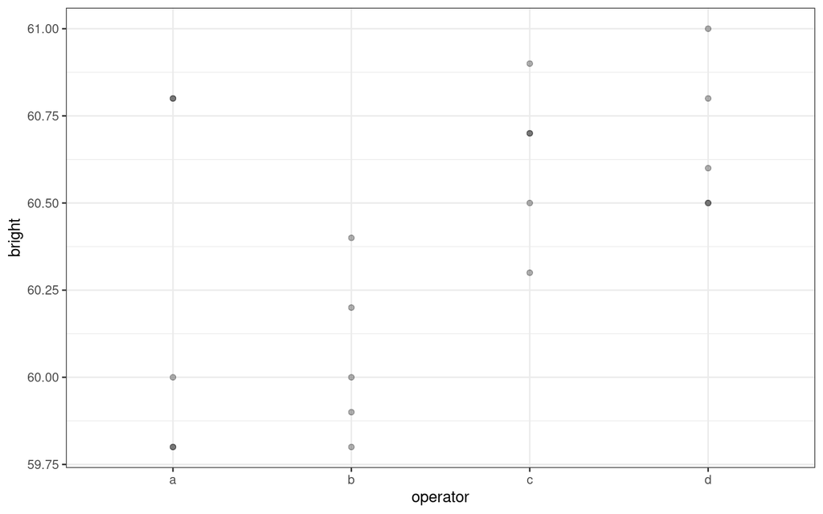

```r
ggplot(pulp) +
  geom_point(aes(x = operator, y = bright), alpha = .3)
```

```r
coef(lmod)
```

```
(Intercept)   operatorb   operatorc   operatord
      60.24       -0.18        0.38        0.44
```

```r
mmod <- lmer(bright ~ 1 + (1 | operator), data = pulp)
summary(mmod)
```

```
Linear mixed model fit by REML ['lmerMod']
Formula: bright ~ 1 + (1 | operator)
   Data: pulp

REML criterion at convergence: 18.6

Scaled residuals:
    Min      1Q  Median      3Q     Max
-1.4666 -0.7595 -0.1244  0.6281  1.6012

Random effects:
 Groups   Name        Variance Std.Dev.
 operator (Intercept) 0.06808  0.2609
 Residual             0.10625  0.3260
Number of obs: 20, groups:  operator, 4

Fixed effects:
            Estimate Std. Error t value
(Intercept)  60.4000     0.1494   404.2
```

```r
lme4::ranef(mmod)$operator  # estimates for alphas
```

```
  (Intercept)
a  -0.1219403
b  -0.2591231
c   0.1676679
d   0.2133955
```

In `mmod`, the fixed effect is just the intercept, and the random effect, represented by `(1 | operator)`, which indicates that the random effect is constant within each group. `lmer` uses REML by default, so the estimates are as expected. $\hat{\sigma}_\alpha^2 \approx (0.447-0.106)/5 \approx 0.0681$ and $\hat{\sigma}^2 \approx 0.1063$ (compare to `aov`—this is because the design is balanced with 5 per level). And finally, for this model, $\hat{\beta} = \hat{\mu} \approx 60.4$.

If we are interested in $\hat{\alpha}_i$ ($i = 1, 2, 3, 4$), we can obtain our predicted random effects by using MLE: $\hat{\alpha} = D Z^T V^{-1} (y - X \beta)$.

Predicted random effects are proportional but smaller than their fixed effects counterparts.

Random effects are also called shrinkage estimates.

Compare this to:

```r
smod <- lmer(bright ~ 1 + (1 | operator), data = pulp, REML = FALSE)
summary(smod)
```

```
Linear mixed model fit by maximum likelihood  ['lmerMod']
Formula: bright ~ 1 + (1 | operator)
   Data: pulp

     AIC      BIC   logLik deviance df.resid
    22.5     25.5     -8.3     16.5       17

Scaled residuals:
     Min       1Q   Median       3Q      Max
-1.50554 -0.78116 -0.06353  0.65850  1.56232

Random effects:
 Groups   Name        Variance Std.Dev.
 operator (Intercept) 0.04575  0.2139
 Residual             0.10625  0.3260
Number of obs: 20, groups:  operator, 4

Fixed effects:
            Estimate Std. Error t value
(Intercept)  60.4000     0.1294   466.7
```

The between-subjects standard deviation is smaller than from the REML method, but the fixed effects are unchanged.

#### Example: Blocks as random effects

Production of penicillin  
Response: yield  
Factor 1: treatment  
Factor 2: blend (blocking variable)

$y_{ij} = \mu + \alpha_i + \tau_j + \epsilon_{ij}$

We treat the treatment as a fixed effect $\alpha$ and blend as a random effect $\tau$

```r
data(penicillin, package = 'faraway')
summary(penicillin)
```

```
 treat    blend       yield
 A:5   Blend1:4   Min.   :77
 B:5   Blend2:4   1st Qu.:81
 C:5   Blend3:4   Median :87
 D:5   Blend4:4   Mean   :86
       Blend5:4   3rd Qu.:89
                  Max.   :97
```

```r
mixmod <- lmer(yield ~ treat + (1 | blend), data = penicillin)
summary(mixmod)
```

```
Linear mixed model fit by REML ['lmerMod']
Formula: yield ~ treat + (1 | blend)
   Data: penicillin

REML criterion at convergence: 103.8

Scaled residuals:
    Min      1Q  Median      3Q     Max
-1.4152 -0.5017 -0.1644  0.6830  1.2836

Random effects:
 Groups   Name        Variance Std.Dev.
 blend    (Intercept) 11.79    3.434
 Residual             18.83    4.340
Number of obs: 20, groups:  blend, 5

Fixed effects:
            Estimate Std. Error t value
(Intercept)   84.000      2.475  33.941
treatB         1.000      2.745   0.364
treatC         5.000      2.745   1.822
treatD         2.000      2.745   0.729

Correlation of Fixed Effects:
       (Intr) treatB treatC
treatB -0.555
treatC -0.555  0.500
treatD -0.555  0.500  0.500
```

#### Example: Nested model

Consistency in laboratory tests

Given jar of dried egg powder  
Response: fat content  
Factor 1: 6 labs  
Factor 2: In each lab, 2 technicians  
Factor 3: Each technician tests 2 samples  
Factor 4: Each sample divided in 2

$y_{ijkl} = \mu + L_i + T_{ij} + S_{ijk} + \epsilon_{ijkl}$

We will treat $L$, $T$, $S$ as random effects

$y = \mathbb{1} \mu \in \mathbb{R}^{48}$

$X = \mathbb{1} \in \mathbb{R}^{48}$

$\beta = \mu$

$Z$ … (see notes)  
Each row corresponds to a lab, technician, and sample  
$\in \mathbb{R}^{48 \times 42}$

$\gamma \in \mathbb{R}^{42}$

$D = \begin{bmatrix} \sigma_L^2 I_6 & & \\ & \sigma_T^2 I_{12} & \\ & & \sigma_S^2 I_{24} \end{bmatrix} \in \mathbb{R}^{42 \times 42}$

#### Example: Panel study of income dynamics (PSID)

Longitudinal study  
85 heads of households

```r
data(psid, package = 'faraway')
summary(psid)
```

```
      age             educ       sex         income            year
 Min.   :25.00   Min.   : 3.00   F:732   Min.   :     3   Min.   :68.00
 1st Qu.:28.00   1st Qu.:10.00   M:929   1st Qu.:  4300   1st Qu.:73.00
 Median :34.00   Median :12.00           Median :  9000   Median :78.00
 Mean   :32.19   Mean   :11.84           Mean   : 13575   Mean   :78.61
 3rd Qu.:36.00   3rd Qu.:13.00           3rd Qu.: 18050   3rd Qu.:84.00
 Max.   :39.00   Max.   :16.00           Max.   :180000   Max.   :90.00
     person
 Min.   : 1.00
 1st Qu.:20.00
 Median :42.00
 Mean   :42.44
 3rd Qu.:63.00
 Max.   :85.00
```

```r
psid$cyear <- psid$year - 78

psid.mod <- lmer(log(income) ~ cyear * sex + age + educ + (cyear | person),
                 data = psid)
summary(psid.mod)
```

```
Linear mixed model fit by REML ['lmerMod']
Formula: log(income) ~ cyear * sex + age + educ + (cyear | person)
   Data: psid

REML criterion at convergence: 3819.8

Scaled residuals:
     Min       1Q   Median       3Q      Max
-10.2310  -0.2134   0.0795   0.4147   2.8254

Random effects:
 Groups   Name        Variance Std.Dev. Corr
 person   (Intercept) 0.2817   0.53071
          cyear       0.0024   0.04899  0.19
 Residual             0.4673   0.68357
Number of obs: 1661, groups:  person, 85

Fixed effects:
             Estimate Std. Error t value
(Intercept)  6.674211   0.543323  12.284
cyear        0.085312   0.008999   9.480
sexM         1.150312   0.121292   9.484
age          0.010932   0.013524   0.808
educ         0.104209   0.021437   4.861
cyear:sexM  -0.026306   0.012238  -2.150

Correlation of Fixed Effects:
           (Intr) cyear  sexM   age    educ
cyear       0.020
sexM       -0.104 -0.098
age        -0.874  0.002 -0.026
educ       -0.597  0.000  0.008  0.167
cyear:sexM -0.003 -0.735  0.156 -0.010 -0.011
```

Note that in this model, `cyear` is both a fixed effect and a random effect

$y$ is income

$x_i = \begin{bmatrix} 1 & cyear_i & sex_i & (cyear \times sex)_i & age_i & educ_i \end{bmatrix}$ and $X = \begin{bmatrix} x_1^T \\ \vdots \\ x_n^T \end{bmatrix}$

$\beta \in \mathbb{R}^6$

$Z = \begin{bmatrix} z_1 & & \\ & \ddots & \\ & & z_{85} \end{bmatrix}$ where

$z_i = \begin{bmatrix} \mathbb{1} & v_i \end{bmatrix}$ and $v_i$ is a vector of years for each person. Note that the dimensionality of $v_i$ varies since the number of years of data varies from person to person. $z_i \in \mathbb{R}^{y \times 2}$ where $y$ is the number of years of data for person $i$.

$\gamma = \begin{bmatrix} \gamma_{01} \\ \gamma_{11} \\ \gamma_{02} \\ \gamma_{12} \\ \vdots \\ \gamma_{0, 85} \\ \gamma_{1, 85} \end{bmatrix}$

$D = \begin{bmatrix} \sigma_1^2 & \sigma_{12} \\ \sigma_{12} & \sigma_2^2 \end{bmatrix}$ and $\tilde{D} = diag(D) \in \mathbb{R}^{170 \times 170}$, note that R gives $\rho_{12}$ rather than $\sigma_{12}$

## Inference

We can specify two models, and put in $H_0$ the one that doesn’t contain a specified component (or specified components), and $H_1$ is the model that contains the component(s). In other words, this is the classical full model vs reduced model comparison. Then we can use the likelihood ratio test statistic:

$$2 (\ell(\hat{\beta}_1, \hat{\sigma}_1, \hat{D}_1 | y) -
\ell(\hat{\beta}_0, \hat{\sigma}_0, \hat{D}_0 | Y))$$

This means we have to use MLE rather than the REML estimation.

The test statistic is approximately $\chi^2$-distributed with degrees of freedom equal to the the difference in the dimensions of the two parameter spaces. But this depends on some assumptions:

- The parameters under the null are not on the bound of any parameter space. So we cannot test $H_0$ : $\hat{\sigma}^2 - 0$. If this assumption is not met, then the $p$-values will be larger than they sohuld be. On the other hand, when testing fixed effects, we sometimes get $p$-values that are smaller than they should be.

Another method of hypothesis testing is based on the sums of squares found in the ANOVA decompositions. But this requires a good amount more of computation or algebra and cannot be used for unbalanced data. Called the *expected mean squares* method.

We can try the $F$-test for the fixed effects, which is done in the `nlme` package. But in this case, the degrees of freedom cannot be known easily, and we cannot say that the null distribution follows the $F$-distribution in this case. This is also less reliable when we have unbalanced data. This is also called the Kenward-Rogers (KR) method.

We can use a bootstrapping method to estimate the $p$-value. If we assume normality for the errors and the random effects, thi is called the *parametric bootstrap*. This is done by simulating the data under the null hypothesis using the fitted parameter estimates many times.

We can also define an AIC for this problem:

$$AIC = -2 \times \max \{\ell | y \} + 2p$$

which can be used for model selection.

R example for parametric bootstrapping:

```r
# null model
nullmod <- lm(bright ~ 1, data = pulp)

lrtstat <- as.numeric(2 * (logLik(smod) - logLik(nullmod)))
p.value <- pchisq(lrtstat, 1, lower = FALSE)
c(lrtstat, p.value)
```

```
[1] 2.5683714 0.1090199
```

But there is some additional uncertainty in this result due to the $\chi^2$ distribution assumption, which may not be true. Instead, we should try:

```r
N <- 1000

y <- simulate(nullmod)

lrstat <- numeric(N)

for (i in seq(N)) {
  y <- unlist(simulate(nullmod))
  bnull <- lm(y ~ 1)
  balt <- lmer(y ~ 1 + (1 | operator), data = pulp, REML = FALSE)
  lrstat[i] <- as.numeric(2 * (logLik(balt) - logLik(bnull)))
}

mean(lrstat < 0.00001)
```

```
[1] 0.713
```

```r
mean(lrstat > 2.5684)  # estimated p-value
```

[output not shown]

```r
sqrt(.019 * .981 / N)  # estimated standard error
```

```
[1] 0.004317291
```

A large proportion of the likelihood ratios are $\approx 0$, so we might say that the null and alternative models give the same result. We can also see that the likelihood ratio test statistic is not $\chi^2$ distributed. But our $p$-value is very small, suggesting that we should reject $H_0$.

We can use a package for this:

```r
library(RLRsim)

exactLRT(smod, nullmod)
```

```
    simulated finite sample distribution of LRT. (p-value based on 10000
    simulated values)

data:
LRT = 2.5684, p-value = 0.0245
```

```r
exactRLRT(mmod)
```

```
    simulated finite sample distribution of RLRT.

    (p-value based on 10000 simulated values)

data:
RLRT = 3.4701, p-value = 0.022
```

```r
lme4::VarCorr(mmod)
```

```
 Groups   Name        Std.Dev.
 operator (Intercept) 0.26093
 Residual             0.32596
```

```r
bsd <- numeric(N)
for (i in seq(N)) {
  y <- unlist(simulate(mmod))
  bmod <- lme4::refit(mmod, y)
  bsd[i] <- as.data.frame(lme4::VarCorr(bmod))$sdcor[1]
}
```

```r
quantile(bsd, c(.025, .975))
```

```
     2.5%     97.5%
0.0000000 0.5034003
```

```r
confint(mmod, method = 'boot')
```

```
                 2.5 %     97.5 %
.sig01       0.0000000  0.5241139
.sigma       0.2086457  0.4255011
(Intercept) 60.1235149 60.7168096
```

## Prediction

Prediction for new operator: $\hat{y}^* = \hat{\mu}$. This is because $E[\alpha] = 0$

Prediction for new observation with a known predictor: $\hat{y}^* = \hat{\mu} + \hat{\alpha}_i$

```r
lme4::fixef(mmod) + lme4::ranef(mmod)$operator
```

```
  (Intercept)
a    60.27806
b    60.14088
c    60.56767
d    60.61340
```